# Ecommerce Revenue Prediction Model

Justin Lovern

November 23, 2015

## **Introduction**

The purpose of this project is to build a model to predict revenue for an ecommerce web site. We will consider several variables while building the model and select the best ones, aiming for something that is both adequately predictive and simple. Once we get the data into an analyzable format, we will split it into a training set and a test set to protect against over-fitting. A rough outline follows:

1. Load in r libraries necessary to perform the analysis
2. Bring the data into r and consolidate it into one table after wrangling it
3. Explore the data with visuals using ggplot2
4. Build a model and test it

Let’s get started…

## Load libraries

```r
library(caret)
```

```r
library(ggplot2)
library(pander)
```

## Load in the data and assign to data frames

The first four data sources came from Google Analytics and were exported to Excel, then saved as a .csv file The SkuCount data was retrieved from an e-commerce company’s data warehouse, formatted, and saved as a .csv file

```r
VTT_Bouncerate_Percentexit <- read.csv("VTT_BouncerateVsPercentexit.csv")
VTT_ConversionAOV <- read.csv("VTT_ConversionVsAOV.csv")
VTT_Revenue <- read.csv("VTT_Revenue.csv")
VTT_Traffic <- read.csv("VTT_Traffic.csv")
VTT_SkuCount <- read.csv("SkuCountbyWk.csv")
```

#### The headers are not the best and we should change the periods to underscores:

```
[1] "Year"        "Week.Index"  "Bounce.Rate" "X..Exit"
```

```
[1] "Year"                      "Week.Index"
[3] "Ecommerce.Conversion.Rate" "Average.Order.Value"
```

```
[1] "Year"       "Week.Index" "Revenue"
```

```
[1] "Year"       "Week.Index" "Sessions"
```

```
[1] "Year"         "Weeknum"      "numberOfSKUs"
```

## Change the headers for these tables and convert necessary variables to the numeric data type.

We need to change some variables to numeric because R reads anything with a period in it as a character data type, which can’t be interpreted for the linear regression we will be doing

#### Change the headers for the bounceRate_percentExit table and convert Bounce Rate and Percent Exit to numeric

```r
names(VTT_Bouncerate_Percentexit) <- c("Year", "Week_Index", "Bounce_Rate", "Percent_Exit")
VTT_Bouncerate_Percentexit$Bounce_Rate <- as.numeric(sub("%", "", VTT_Bouncerate_Percentexit$Bounce_Rate))/100
VTT_Bouncerate_Percentexit$Percent_Exit <- as.numeric(sub("%", "", VTT_Bouncerate_Percentexit$Percent_Exit))/100
```

#### Change the headers for the ConversionAOV table and convert Conversion and AOV to numeric

```r
names(VTT_ConversionAOV) <- c("Year", "Week_Index", "Conversion", "AOV")
VTT_ConversionAOV$Conversion <- as.numeric(sub("%", "", VTT_ConversionAOV$Conversion))/100
VTT_ConversionAOV$AOV <- as.numeric(sub("\\$", "", VTT_ConversionAOV$AOV))
```

#### Change the headers for the revenue table and convert Revenue column to numeric

```r
names(VTT_Revenue) <- c("Year", "Week_Index", "Revenue")
VTT_Revenue$Revenue <- sub("\\$", "", VTT_Revenue$Revenue)
VTT_Revenue$Revenue <- as.numeric(sub(",", "", VTT_Revenue$Revenue))
```

#### Change the headers for the traffic table and convert Traffic column to numeric

```r
names(VTT_Traffic) <- c("Year", "Week_Index", "Traffic")
VTT_Traffic$Traffic <- as.numeric(sub(",", "", VTT_Traffic$Traffic))
```

#### Change the headers for the SkuCount table

```r
names(VTT_SkuCount) <- c("Year", "Week_Index", "SkuCount")
```

#### The column headers now look better:

```
[1] "Year"         "Week_Index"   "Bounce_Rate"  "Percent_Exit"
```

```
[1] "Year"       "Week_Index" "Conversion" "AOV"
```

```
[1] "Year"       "Week_Index" "Revenue"
```

```
[1] "Year"       "Week_Index" "Traffic"
```

```
[1] "Year"       "Week_Index" "SkuCount"
```

### Build Summary Table

We now need to combine all these data frames into one for analysis

```r
SummaryTable_VTT <- VTT_Bouncerate_Percentexit
SummaryTable_VTT$Conversion <- VTT_ConversionAOV$Conversion
SummaryTable_VTT$AOV <- VTT_ConversionAOV$AOV
SummaryTable_VTT$Revenue <- VTT_Revenue$Revenue
SummaryTable_VTT$Traffic <- VTT_Traffic$Traffic
SummaryTable_VTT$SkuCount <- VTT_SkuCount$SkuCount
```

#### Output of the first five rows of the summary table:

```
  Year Week_Index Bounce_Rate Percent_Exit Conversion   AOV  Revenue
1 2010         41      0.4841       0.3481     0.0304 69.59 35768.04
2 2010         42      0.2544       0.1780     0.0335 69.29 39080.49
3 2010         43      0.2881       0.1826     0.0249 71.30 44348.08
4 2010         44      0.2573       0.1763     0.0251 71.49 41823.18
5 2010         45      0.2762       0.1804     0.0262 66.73 40103.09
  Traffic SkuCount
1   16908      142
2   16853      139
3   24947      146
4   23292      137
5   22912      154
```

#### Structure of the summary table:

```
'data.frame':   265 obs. of  9 variables:
 $ Year        : int  2010 2010 2010 2010 2010 2010 2010 2010 2010 2010 ...
 $ Week_Index  : int  41 42 43 44 45 46 47 48 49 50 ...
 $ Bounce_Rate : num  0.484 0.254 0.288 0.257 0.276 ...
 $ Percent_Exit: num  0.348 0.178 0.183 0.176 0.18 ...
 $ Conversion  : num  0.0304 0.0335 0.0249 0.0251 0.0262 0.0259 0.0253 0.0256 0.0299 0.03 ...
 $ AOV         : num  69.6 69.3 71.3 71.5 66.7 ...
 $ Revenue     : num  35768 39080 44348 41823 40103 ...
 $ Traffic     : num  16908 16853 24947 23292 22912 ...
 $ SkuCount    : int  142 139 146 137 154 141 141 139 147 159 ...
```

## Create Visuals

### Boxplot - Conversion Vs. Year

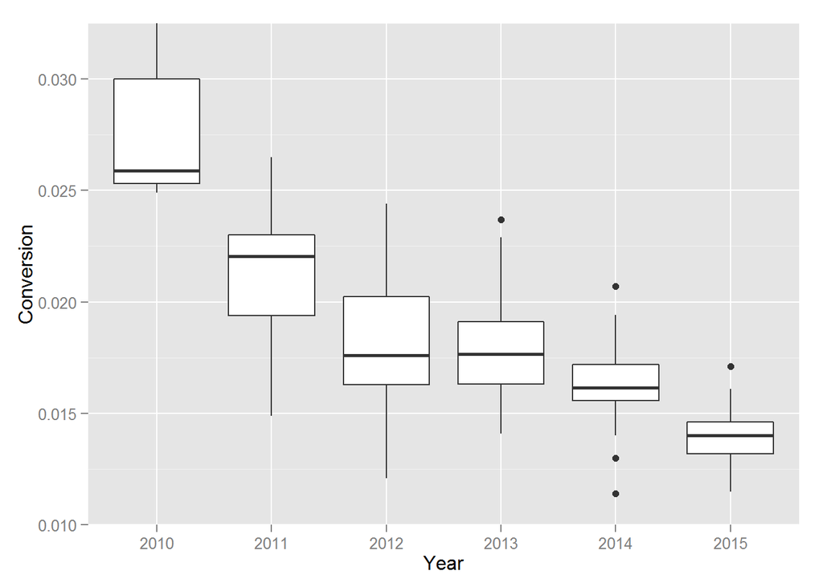

```r
qplot(x = as.factor(Year), y = Conversion, data = SummaryTable_VTT, xlab = "Year",
            geom = 'boxplot') +
       coord_cartesian(ylim = c(.01, .0325))
```

#### It is clear that the conversion rate has been decreasing over time. We also see that the inter-quartile range has been decreasing over time. I am not sure what could explain that.

### Line graphs - Rev Vs. SkuCount and Rev Vs. SkuCount by Year

#### Rev Vs. SkuCount

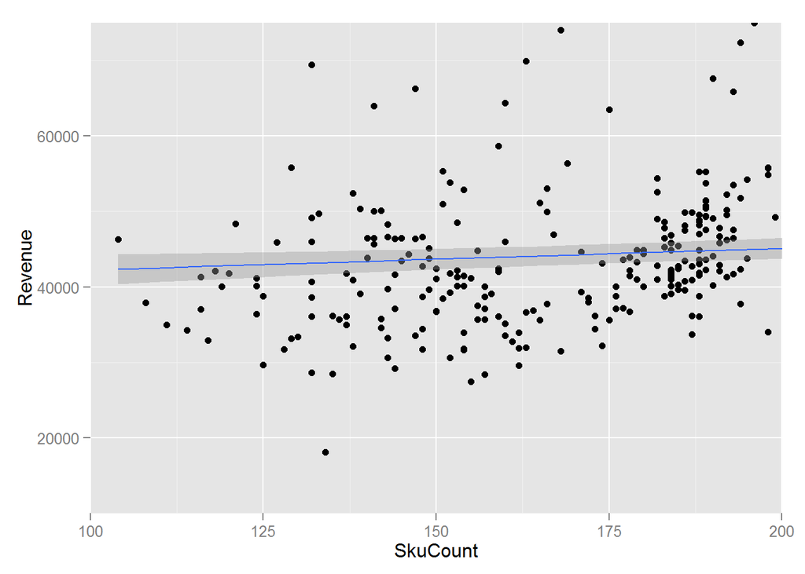

```r
ggplot(aes(x = SkuCount, y = Revenue), data = SummaryTable_VTT) +
       geom_point() +
       geom_smooth(method = 'lm') +
       coord_cartesian(xlim = c(100, 200), ylim = c(10000, 75000))
```

#### This shows a slight positive correlation between SkuCount and Revenue

#### Rev Vs. SkuCount by Year

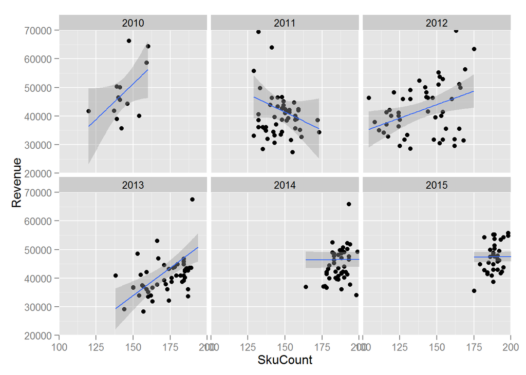

```r
ggplot(aes(x = SkuCount, y = Revenue), data = SummaryTable_VTT) +
       facet_wrap(~Year) +
       geom_point() +
       geom_smooth(method = 'lm') +
       coord_cartesian(xlim = c(100,200), ylim = c(20000, 70000))
```

#### When this is broken out by year it becomes a less clear picture. This suggests that Sku count has little effect on revenue

### Line graphs - Traffic Vs. Conversion and Traffic Vs. Conversion by Year

#### Traffic Vs. Conversion

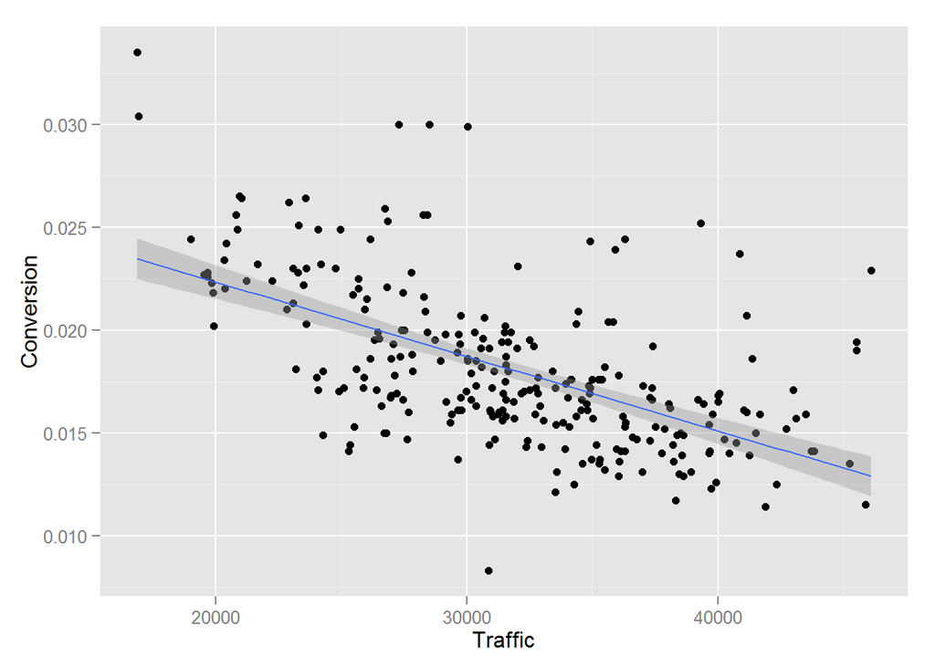

```r
ggplot(aes(x = Traffic, y = Conversion), data = SummaryTable_VTT) +
       geom_point() +
       geom_smooth(method = 'lm') +
       coord_cartesian()
```

#### There appears to be a strong negative correlation between the amount of traffic and the conversion rate. This suggests that the additional traffic coming in is of low quality (i.e., a demographic that is less likely to make a purchase). If the losses in conversion are not low enough to offset the increase in traffic then the additional traffic provides no net-positive value

#### Traffic Vs. Conversion by Year

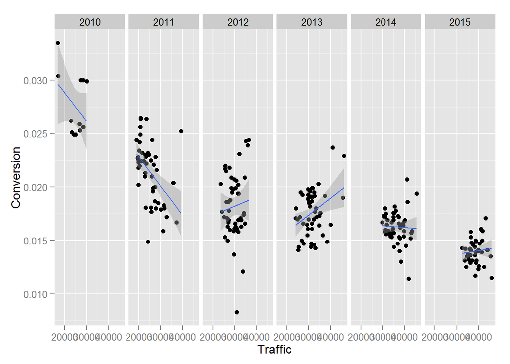

```r
ggplot(aes(x = Traffic, y = Conversion), data = SummaryTable_VTT) +
       facet_grid(~Year) +
       geom_point() +
       geom_smooth(method = 'lm') +
       coord_cartesian()
```

#### Here you can see that conversion has been declining YOY, but traffic has been increasing (note that in 2010 the line starts on the left of the graph and ends in the middle, whereas in 2015 the line starts in the middle of the graph and ends on the right)

##### Breaking it up by year makes it appear that there are other variables affecting the conversion rate

### Line graphs - Traffic Vs. Rev and Traffic Vs. Rev by Year

#### Traffic Vs. Revenue

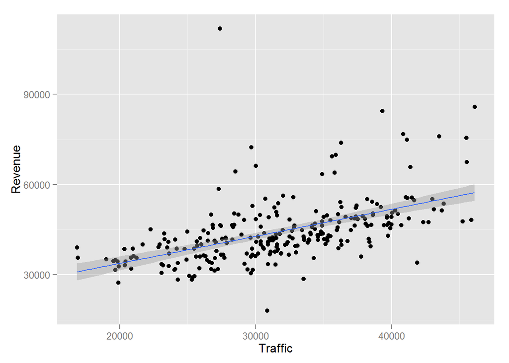

```r
ggplot(aes(x = Traffic, y = Revenue), data = SummaryTable_VTT) +
       geom_point() +
       geom_smooth(method = 'lm') +
       coord_cartesian()
```

#### There appears to be a positive correlation between traffic and revenue

#### Traffic Vs. Revenue by Year

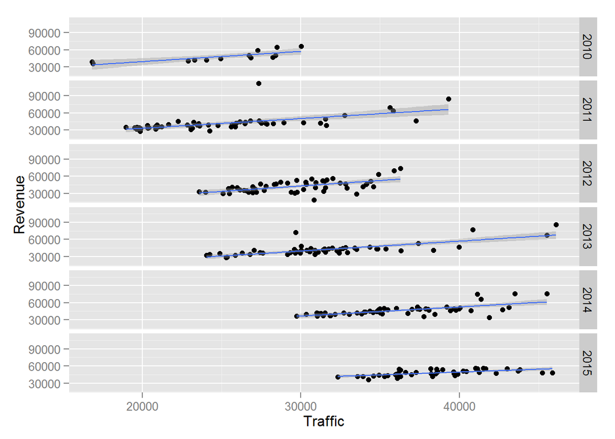

```r
ggplot(aes(x = Traffic, y = Revenue), data = SummaryTable_VTT) +
       facet_grid(Year~.) +
       geom_point() +
       geom_smooth(method = 'lm') +
       coord_cartesian()
```

#### Breaking it out by year shows that each year there was a positive correlation and that traffic has been increasing. It’s clear at this point that additional traffic increases revenue, but other factors (such as conversion) must remain the same if revenue is going to increase

### Seasonality Trend

#### Let’s see if there is any weekly seasonality to the revenue

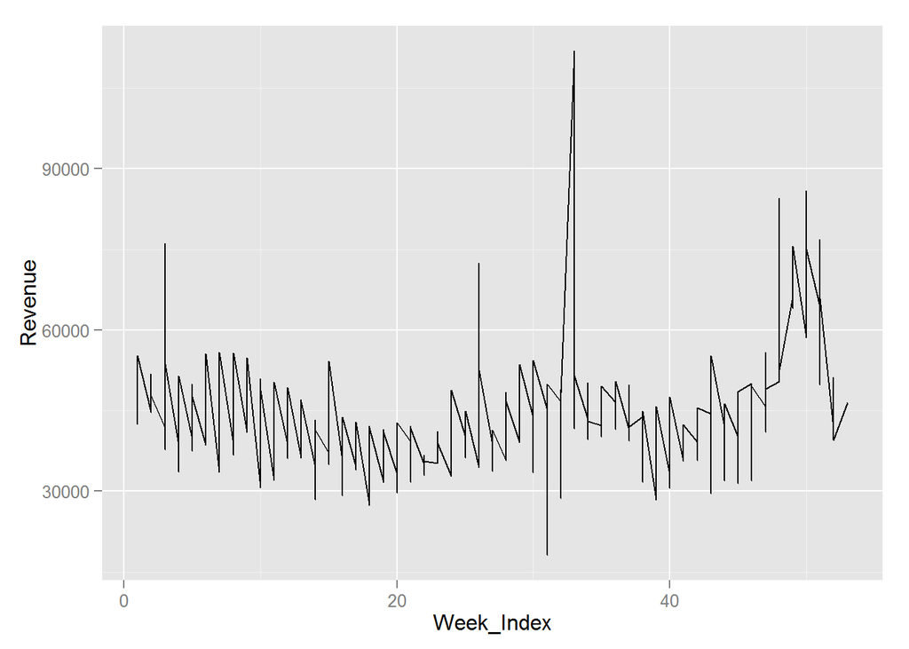

```r
ggplot(aes(x = Week_Index, y = Revenue), data = SummaryTable_VTT) +
       geom_line() +
       coord_cartesian()
```

#### We do see some weekly seasonality. It looks like there is a base revenue somewhere around the 40K mark, with dips around the 20th week of the year and a bump at the end during holiday season. Let’s break this out by year to smooth it out:

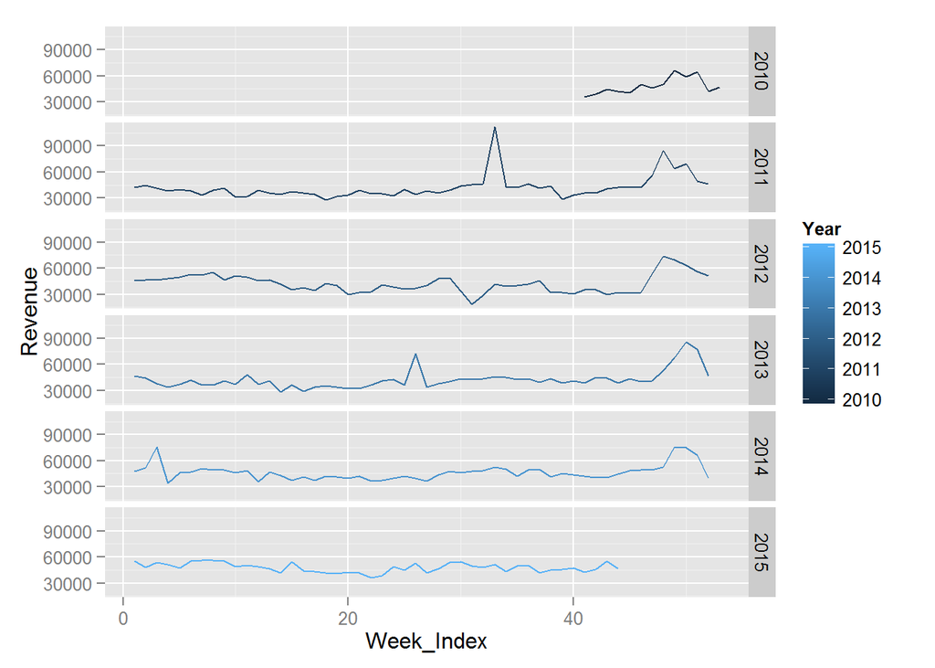

```r
ggplot(aes(x = Week_Index, y = Revenue), data = SummaryTable_VTT) +
       facet_grid(Year~.) +
       geom_line(aes(color = Year)) +
       coord_cartesian()
```

#### There is definitely some seasonal lift towards the end of the year, correlating to the holiday season. Beyond that it is difficult to see

### Conversion Seasonality

#### I wanted to see if there was any seasonality in the conversion rates

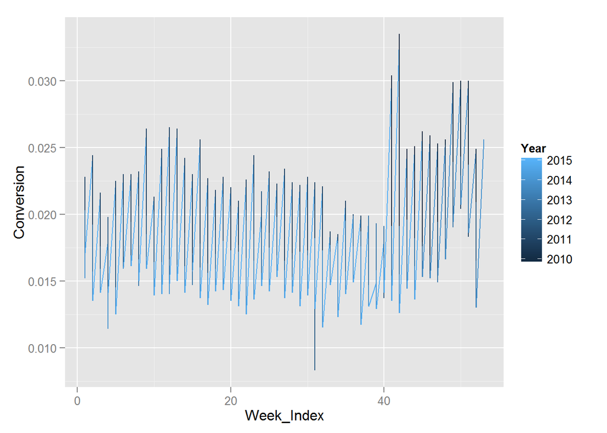

```r
ggplot(aes(x = Week_Index, y = Conversion, color = Year), data = SummaryTable_VTT) +
       geom_line() +
       coord_cartesian()
```

#### There does appear to be some seasonality in the conversion rates showing a definite drop in weeks 30-40 (end of July to mid-September), with a spike right around Black Friday/Cyber Monday and an elevation during the holiday period

##### Let’s see how this looks broken up by year:

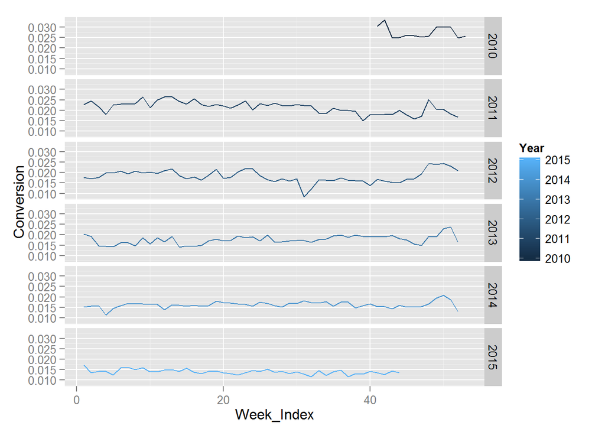

```r
ggplot(aes(x = Week_Index, y = Conversion, color = Year), data = SummaryTable_VTT) +
       facet_grid(Year~.) +
       geom_line() +
       coord_cartesian()
```

## Build a linear regression model

### We will first split the summary table into a training set and a test set to prevent overfitting and then test it (using the Caret library)

#### Split the data

```r
set.seed(55)
VTT_TrainIndex <- createDataPartition(SummaryTable_VTT$Revenue, p = .8, list = FALSE)
VTT_Train <- SummaryTable_VTT[VTT_TrainIndex,]
VTT_Test <- SummaryTable_VTT[-VTT_TrainIndex,]
```

#### Build models and select the best

##### Let’s take a look at a few models and then select the best. The goal is to end up with a predictive model that is also simple (i.e., fewest number of variables possible). With this in mind, our approach will be to build our first model using ALL the variables as predictors and then removing the least ‘significant’ variable’ and building a new model until we get down to something that is both satisfactorily predictive and simple. We will be measuring the predictive power of the model with the adjusted $r^{2}$ measure. In general, anything above .7 is very good.

##### Note: The significance of a variable is denoted by the p-value (notated as Pr(>|t|) below). The smaller the p-value, the more significant the variable.

##### Let’s take a look at our first model using all the variables in the data set to predict revenue:

```r
pander(summary(lm(Revenue ~ ., data = VTT_Train)))
```

|  | Estimate | Std. Error | t value | Pr(>\|t\|) |
| --- | --- | --- | --- | --- |
| **Year** | -299.4 | 227.1 | -1.318 | 0.1889 |
| **Week_Index** | 20.62 | 11.35 | 1.816 | 0.07079 |
| **Bounce_Rate** | -16443 | 10641 | -1.545 | 0.1238 |
| **Percent_Exit** | 10133 | 14104 | 0.7184 | 0.4733 |
| **Conversion** | 2199882 | 63926 | 34.41 | 6.782e-87 |
| **AOV** | 533.2 | 12.4 | 42.99 | 3.223e-104 |
| **Traffic** | 1.597 | 0.04425 | 36.09 | 1.597e-90 |
| **SkuCount** | -5.702 | 2.796 | -2.039 | 0.0427 |
| **(Intercept)** | 518723 | 456234 | 1.137 | 0.2569 |

Fitting linear model: Revenue ~ .

| Observations | Residual Std. Error | $R^2$ | Adjusted $R^2$ |
| --- | --- | --- | --- |
| 213 | 2185 | 0.9617 | 0.9602 |

##### The adjusted $r^{2}$ looks fantastic, but lets remove Percent_Exit (the least significant variable):

```r
pander(summary(lm(Revenue ~ . - Percent_Exit, data = VTT_Train)))
```

|  | Estimate | Std. Error | t value | Pr(>\|t\|) |
| --- | --- | --- | --- | --- |
| **Year** | -325.3 | 224 | -1.452 | 0.148 |
| **Week_Index** | 19.76 | 11.28 | 1.753 | 0.08115 |
| **Bounce_Rate** | -9848 | 5375 | -1.832 | 0.06837 |
| **Conversion** | 2203769 | 63621 | 34.64 | 1.266e-87 |
| **AOV** | 532.9 | 12.38 | 43.04 | 1.277e-104 |
| **Traffic** | 1.591 | 0.0434 | 36.67 | 5.474e-92 |
| **SkuCount** | -5.602 | 2.789 | -2.009 | 0.04589 |
| **(Intercept)** | 570885 | 449887 | 1.269 | 0.2059 |

Fitting linear model: Revenue ~ . - Percent_Exit

| Observations | Residual Std. Error | $R^2$ | Adjusted $R^2$ |
| --- | --- | --- | --- |
| 213 | 2182 | 0.9616 | 0.9603 |

##### The $r^{2}$ is essentially the same and there are still some insignificant variables. Let’s remove Year (the next least significant variable):

```r
pander(summary(lm(Revenue ~ . - Percent_Exit - Year, data = VTT_Train)))
```

|  | Estimate | Std. Error | t value | Pr(>\|t\|) |
| --- | --- | --- | --- | --- |
| **Week_Index** | 24.95 | 10.72 | 2.327 | 0.02095 |
| **Bounce_Rate** | -13523 | 4754 | -2.844 | 0.004899 |
| **Conversion** | 2229265 | 61315 | 36.36 | 1.391e-91 |
| **AOV** | 534.1 | 12.39 | 43.1 | 4.825e-105 |
| **Traffic** | 1.578 | 0.04259 | 37.06 | 4.621e-93 |
| **SkuCount** | -6.778 | 2.676 | -2.533 | 0.01207 |
| **(Intercept)** | -82427 | 2414 | -34.15 | 9.054e-87 |

Fitting linear model: Revenue ~ . - Percent_Exit - Year

| Observations | Residual Std. Error | $R^2$ | Adjusted $R^2$ |
| --- | --- | --- | --- |
| 213 | 2188 | 0.9612 | 0.9601 |

##### The adjusted $r^{2}$ remains virtually the same and all the variables are significant. Let’s keep removing the least significant variables one by one and re-evaluating the $r^{2}$ as we go. The below model has the Week_Index removed:

```r
pander(summary(lm(Revenue ~ . - Percent_Exit - Year - Week_Index, data = VTT_Train)))
```

|  | Estimate | Std. Error | t value | Pr(>\|t\|) |
| --- | --- | --- | --- | --- |
| **Bounce_Rate** | -12024 | 4761 | -2.526 | 0.01229 |
| **Conversion** | 2269011 | 59512 | 38.13 | 1.501e-95 |
| **AOV** | 535.3 | 12.51 | 42.79 | 9.158e-105 |
| **Traffic** | 1.588 | 0.04285 | 37.05 | 2.597e-93 |
| **SkuCount** | -8.075 | 2.645 | -3.053 | 0.002564 |
| **(Intercept)** | -83239 | 2414 | -34.48 | 9.513e-88 |

Fitting linear model: Revenue ~ . - Percent_Exit - Year - Week_Index

| Observations | Residual Std. Error | $R^2$ | Adjusted $R^2$ |
| --- | --- | --- | --- |
| 213 | 2211 | 0.9602 | 0.9593 |

##### The adjusted $r^{2}$ is still very high. Let’s remove Bounce_Rate and keep going:

```r
pander(summary(lm(Revenue ~ . - Percent_Exit - Year - Week_Index - Bounce_Rate, data = VTT_Train)))
```

|  | Estimate | Std. Error | t value | Pr(>\|t\|) |
| --- | --- | --- | --- | --- |
| **Conversion** | 2360660 | 47777 | 49.41 | 6.808e-117 |
| **AOV** | 528.2 | 12.35 | 42.78 | 4.734e-105 |
| **Traffic** | 1.518 | 0.03334 | 45.55 | 3.639e-110 |
| **SkuCount** | -7.814 | 2.677 | -2.919 | 0.003902 |
| **(Intercept)** | -86999 | 1924 | -45.21 | 1.503e-109 |

Fitting linear model: Revenue ~ . - Percent_Exit - Year - Week_Index - Bounce_Rate

| Observations | Residual Std. Error | $R^2$ | Adjusted $R^2$ |
| --- | --- | --- | --- |
| 213 | 2240 | 0.959 | 0.9582 |

##### Still a great model, let’s remove SkuCount:

```r
pander(summary(lm(Revenue ~ . - Percent_Exit - Year - Week_Index - Bounce_Rate - SkuCount, data = VTT_Train)))
```

|  | Estimate | Std. Error | t value | Pr(>\|t\|) |
| --- | --- | --- | --- | --- |
| **Conversion** | 2365428 | 48601 | 48.67 | 5.482e-116 |
| **AOV** | 529.7 | 12.56 | 42.18 | 3.335e-104 |
| **Traffic** | 1.482 | 0.03141 | 47.17 | 2.253e-113 |
| **(Intercept)** | -87399 | 1954 | -44.73 | 5.307e-109 |

Fitting linear model: Revenue ~ . - Percent_Exit - Year - Week_Index - Bounce_Rate - SkuCount

| Observations | Residual Std. Error | $R^2$ | Adjusted $R^2$ |
| --- | --- | --- | --- |
| 213 | 2280 | 0.9573 | 0.9567 |

##### Let’s run with this one. The adjusted $r^{2}$ is very high and this model only requires three variables.

Here is the final model, rewritten for simplification:

```r
model <- lm(Revenue ~ Conversion + AOV + Traffic, data = VTT_Train)
```

|  | Estimate | Std. Error | t value | Pr(>\|t\|) |
| --- | --- | --- | --- | --- |
| **Conversion** | 2365428 | 48601 | 48.67 | 5.482e-116 |
| **AOV** | 529.7 | 12.56 | 42.18 | 3.335e-104 |
| **Traffic** | 1.482 | 0.03141 | 47.17 | 2.253e-113 |
| **(Intercept)** | -87399 | 1954 | -44.73 | 5.307e-109 |

Fitting linear model: Revenue ~ Conversion + AOV + Traffic

| Observations | Residual Std. Error | $R^2$ | Adjusted $R^2$ |
| --- | --- | --- | --- |
| 213 | 2280 | 0.9573 | 0.9567 |

#### Create test output

##### We now need to test the model we built on the test set we created earlier to see if this model fits to ‘new’ data. If the resulting adjusted $r^{2}$ is still high then we have a good model

```r
predictTest <- predict(model, newdata = VTT_Test)
```

#### Calc $r^{2}$ for test set

```r
SSE <- sum((VTT_Test$Revenue - predictTest)^2)
SST <- sum((VTT_Test$Revenue - mean(SummaryTable_VTT$Revenue))^2)
1 - SSE/SST
```

```
[1] 0.9169399
```